# Analisi del campionato di basket NCAA (1985-2020)

## Campionato di basket NCAA

## Division I

Il campionato di basket dell’NCAA (National Collegiate Athletic Association) è diviso in tre categorie:

- Division I
- Division II
- Division III

## Regular Season

La prima parte di stagione, la Regular Season, si divide in due periodi:

- non conference schedule
- conference schedule

Questo periodo è fondamentale per poter giocare la seconda parte di stagione.

## March Madness

La seconda parte di stagione è divisa anch’essa in due parti:

- conference tournament
- March Madness

## Analisi del campionato tra il 1985 ed oggi

## Fattore campo

Il fattore campo è spesso considerato fondamentale, una marcia in più per la squadra di casa, che conosce lo stadio in cui viene disputata la partita, ma sopratutto ha il sostegno del pubblico amico.

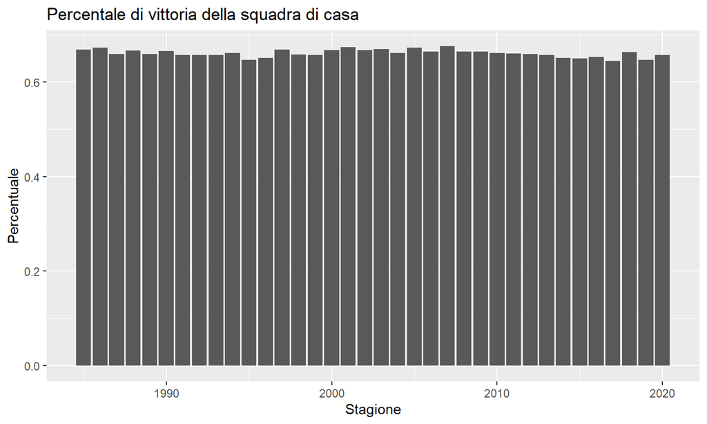

#### Rapporto medio di vittorie in casa

```
## [1] 0.6607463
```

## Squadre vincenti

Ogni college cerca di attrarre i migliori talenti delle High School, in modo da essere ogni stagione sempre più competitivo.

#### Squadre con il win rate più alto dal 1985 ad oggi

| TeamName | Rate | Rank |
| --- | --- | --- |
| Kansas | 0.8112199 | 1 |
| Duke | 0.8080279 | 2 |
| Kentucky | 0.7692308 | 3 |
| Arizona | 0.7556155 | 4 |
| Gonzaga | 0.7457306 | 5 |
| North Carolina | 0.7456294 | 6 |
| Syracuse | 0.7248442 | 7 |
| Xavier | 0.7062615 | 8 |
| Michigan St | 0.6973564 | 9 |
| Memphis | 0.6892253 | 10 |

## Cambiamento del gioco negli anni - Tipi di tiri effettuati

Con il passare degli anni, tra l’85 ed oggi, è anche cambiato il modo di giocare a basket, insieme alle regole e alle strategie in campo.

[figure not shown]

## Cambiamento del gioco negli anni - Punteggio

Le modifiche del gioco hanno influenzato però anche i punteggi?

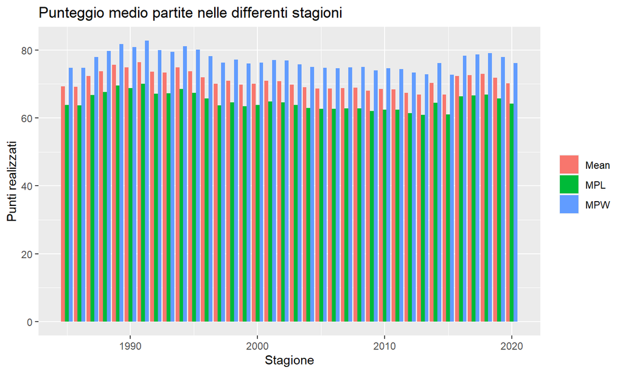

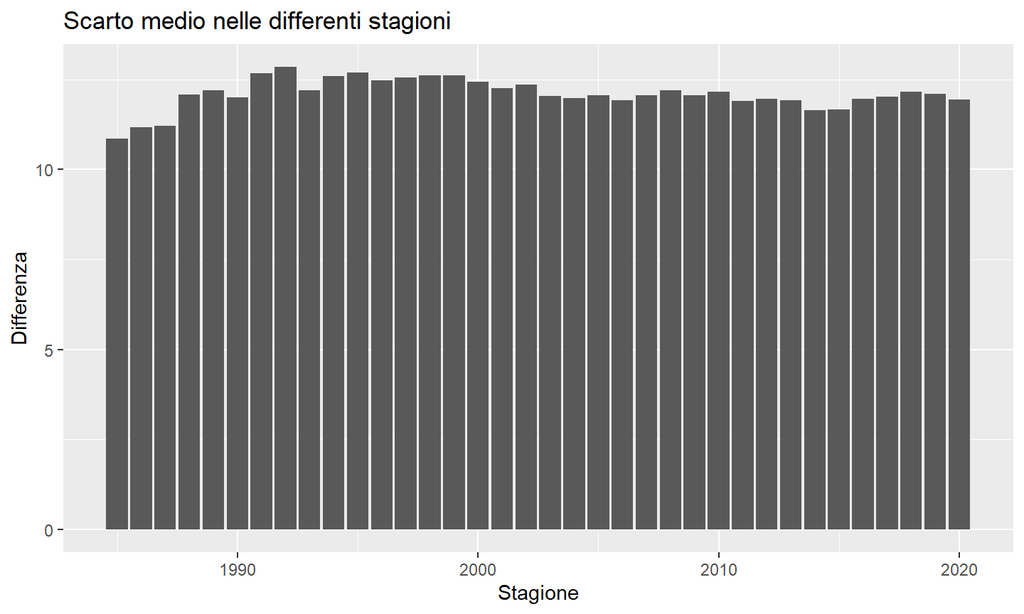

## Cambiamento del gioco negli anni - Punteggio RS-MM

La RS è giocata allo stesso modo della MM?

- MPW = Media punti team vincente
- MPL = Media punti team perdente
- MPPG = Media punti per game

#### Diverse correlazioni tra i punteggi della RS e della MM

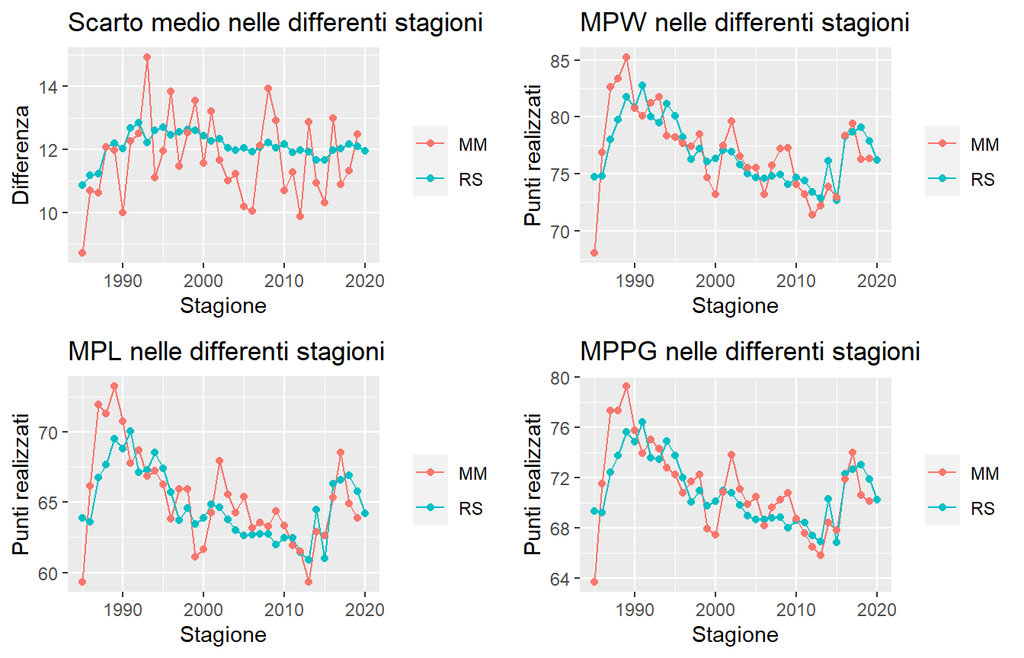

## Round MM

Il bracket della MM è diviso in 4 Regioni, che indicano la diversa provenienza dei college. Negli ultimi anni sono:

- East
- MiddleWest
- South
- West

Durante la March Madness si svolgono diversi round:

- top 64 - First round
- top 32 - Second round
- top 16 - Sweet Sixteen
- top 8 - Elite Eight
- top 4 - Final Four
- top 2 - Final

#### Bracket

[figure not shown]

#### Analisi dei vari tipi di punteggio durante i round della MM

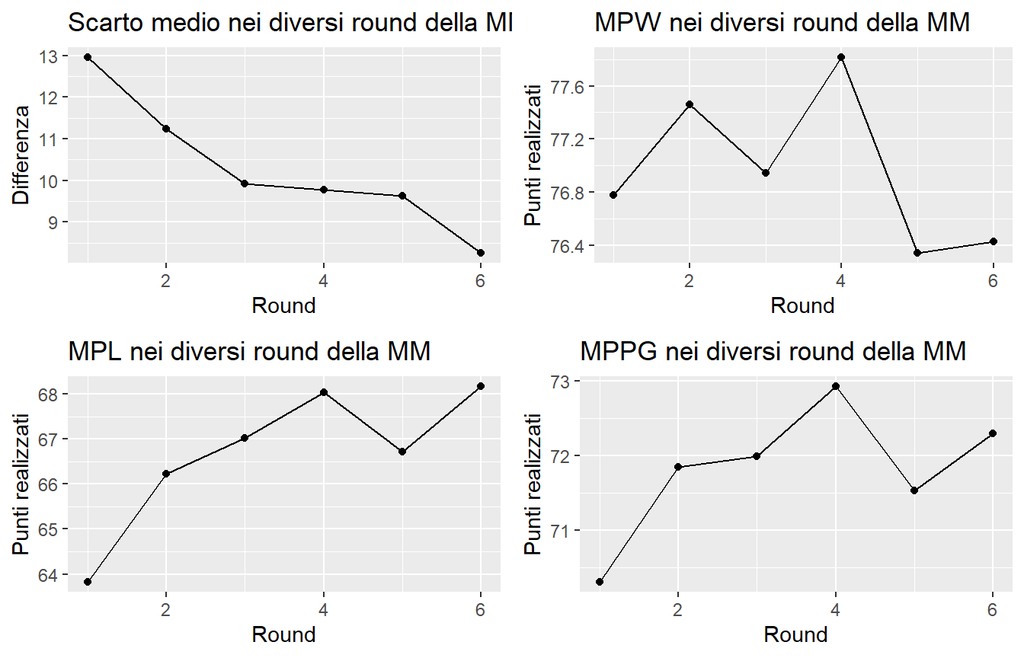

## Maggior numero di presenze alla MM

Un ateneo può partecipare alla March Madness in due modi:

- vincere il Conference Tournament
- venire scelti dai Commissioner

In questo modo vengono scelte le 64/68 squadre che parteciperanno al torneo conclusivo della manifestazione e, per ogni Regione, viene stilata una classifica dai Commissioner che indica l’assegnazione della Seed.

#### Squadre con il maggior numero di partecipazioni alla MM dal 1985 ad oggi

| TeamName | N_partecipazioni |
| --- | --- |
| Duke | 34 |
| Kansas | 34 |
| Arizona | 32 |
| North Carolina | 32 |
| Kentucky | 30 |
| Michigan St | 29 |
| Syracuse | 28 |
| Louisville | 26 |
| Oklahoma | 26 |
| Purdue | 26 |

#### Squadre con il maggior numero di partecipazioni alla MM negli ultimi 10 anni

| TeamName | N_partecipazioni |
| --- | --- |
| Duke | 10 |
| Gonzaga | 10 |
| Kansas | 10 |
| Michigan St | 10 |
| Cincinnati | 9 |
| Kentucky | 9 |
| North Carolina | 9 |
| Villanova | 9 |
| Wisconsin | 9 |
| Florida | 8 |

## Squadre che hanno vinto di più

| TeamName | Rank | N_Championship |
| --- | --- | --- |
| Duke | 2 | 5 |
| North Carolina | 6 | 4 |
| Connecticut | 18 | 4 |
| Kentucky | 3 | 3 |
| Villanova | 20 | 3 |
| Kansas | 1 | 2 |
| Louisville | 12 | 2 |
| Florida | 23 | 2 |
| Arizona | 4 | 1 |
| Syracuse | 7 | 1 |

## Analisi 2018-19

## Confronto del win rate con l’elo rate

##### Modifiche apportate all’elo rating system

Vincente squadra in casa

\(update = (k * (1 - mu*(0.66)/(0.32*mu+0.34))) * 2 / (2 - (score / maxDiff))\)

Vincente squadra fuori casa

\(update = (k * (1 - mu*(1-0.66)/(0.32*mu+0.34))) * 2 / (2 - (score / maxDiff))\)

- mu = calcolo match up con il classico elo rating system
- 0.66 = probabilità di vittoria da parte della squadra di casa
- score = risultato della partita come differenza tra il punteggio della squadra vincente e quello della squadra perdente
- maxDiff = mediana dell’1% dei game con la più alta differenza tra il 1985 e il 2018

#### Le squadre qualificate alla MM, divise per Region ed ordinate per Seed

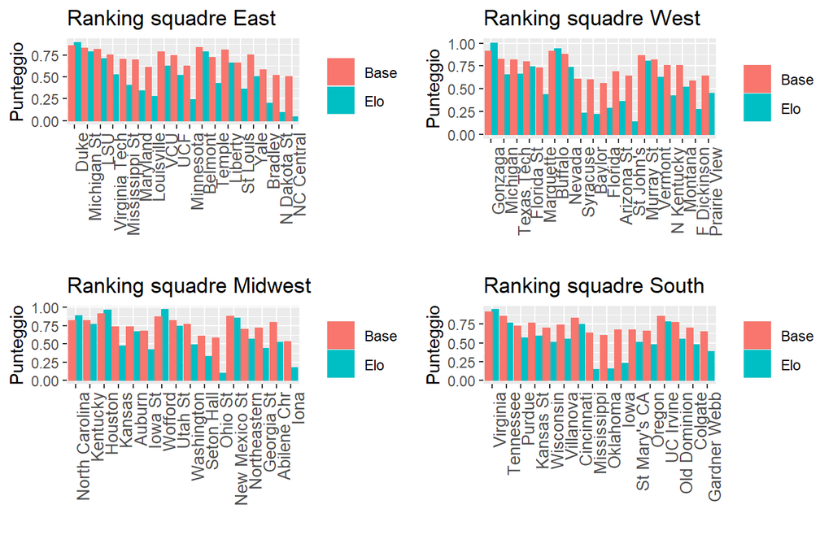

## Comparazione Win Rate - Elo Rate - Seed

Supponendo di dover predire i risultati del bracket dello scorso anno ho utilizzato tre metodi:

1. vincente chi ha il Win Rate maggiore
2. vincente chi ha l’Elo Rate maggiore
3. vincente chi ha la Seed minore

#### Numero di prediction corrette secondo i vari metodi

```
## [1] 40 43 47
```

## Ja Morant

## Statistiche Ja Morant

Un *playmaker*, classe ’99, molto atletico ed esplosivo, con delle doti da passatore invidiabili da chiunque, un giocatore estremamente completo. Lo scorso anno era la stella di Murray State, e, insieme ai suoi compagni, ha portato l’ateneo a giocarsi un posto nelle *Sweet Sixteen*, perdendo contro Florida State.

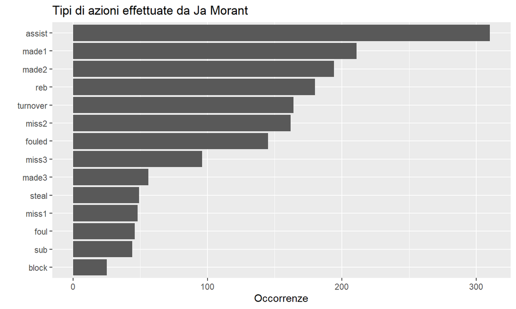

## Distribuzione su metà campo tiri Ja Morant

[figure not shown]

## Distribuzionione su metà campo tiri effettuati - Stagione 2018-19

[figure not shown]